# File Handling

==> Sometimes, it is not enough to only display the data on the console. The data to be displayed may be very large, and only a limited amount of data can be displayed on the console, and since the memory is volatile, it is impossible to recover the programmatically generated data again and again.

==> However, if we need to do so, we may store it onto the local file system which is volatile and can be accessed every time. Here, comes the need of file handling.

==> File handling is an important part of any web application.

==> Python has several functions for creating, reading, updating, and deleting files.

==> Hence, in Python, a file operation takes place in the following order.

```
==> Open a file
==> Read or write (perform operation)
==> Close the file
```

#### Python file modes

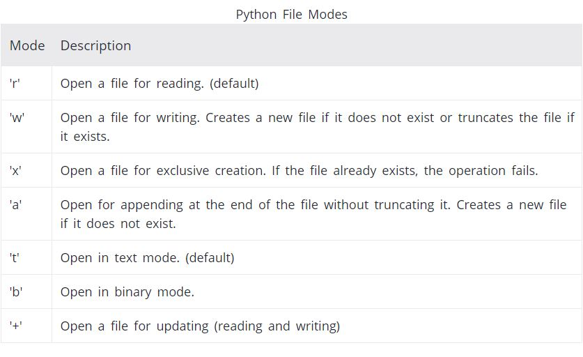

## Opening a file

==> Python has a built-in function open() to open a file. This function returns a file object, also called a handle, as it is used to read or modify the file accordingly.

#### Example

==> f = open("test.txt") # open file in current directory

==> f = open("C:/user/RK/test.txt") # specifying full path

==> We can specify the mode while opening a file. In mode, we specify whether we want to read 'r', write 'w' or append 'a' to the file.

==> We also specify if we want to open the file in text mode or binary mode.

==> The default is reading in text mode. In this mode, we get strings when reading from the file.

==> **"r" - Read - Default value. Opens a file for reading, error if the file does not exist**

==> **"a" - Append - Opens a file for appending, creates the file if it does not exist**

==> **"w" - Write - Opens a file for writing, creates the file if it does not exist**

==> **"x" - Create - Creates the specified file, returns an error if the file exists**

```python
## file name one.txt
file = open('one.txt', "r")
# This will print every line one by one in the file
for each_line in file:
    print (each_line)
file.close()
```

```
Hello World!!!This will add this line
```

```python
fileptr = open("one.txt","r")

if fileptr:
    print("file is opened successfully")
fileptr.close()
```

```
file is opened successfully
```

## Closing a file

==> Once all the operations are done on the file, we must close it through our python script using the **close()** method. Any unwritten information gets destroyed once the **close()** method is called on a file object.

==> We can perform any operation on the file externally in the file system is the file is opened in python, hence it is good practice to close the file once all the operations are done.

```python
fileptr = open("one.txt","r")

if fileptr:
    print("file is opened successfully")

#closes the opened file
fileptr.close()
if fileptr:
    print("file is Closed successfully")
```

```
file is opened successfully
file is Closed successfully
```

## Reading the file

==> here is more than one way to read a file in Python. If you need to extract a string that contains all characters in the file then we can use **file.read()**.

==> To read a file using the python script, the python provides us the **read()** method. The read() method reads a string from the file. It can read the data in the text as well as binary format.

```python
fileptr = open("one.txt","r");

#stores all the data of the file into the variable content
content = fileptr.read(5);

# prints the type of the data stored in the file
print(type(content))

#prints the content of the file
print(content)

#closes the opened file
fileptr.close()
```

```
<class 'str'>
Hello
```

```python
file = open("one.txt", "r")
print (file.read())
file.close()
```

```
Hello World!!!
```

==> Another way to read a file is to call a certain number of characters like in the following code the interpreter will read the first five characters of stored data and return it as a string

```python
file = open("one.txt", "r")
print (file.read(5) )
file.close()
```

```
Hello
```

==> You can return one line by using the **readline()** method:

```python
f = open("one.txt", "r")
print(f.readline())
f.close()
```

```
Hello World!!!This will add this line
```

==> By looping through the lines of the file, we can read the whole file.

```python
fileptr = open("one.txt","r");

#running a for loop
for i in fileptr:
    print(i) # i contains each line of the file
fileptr.close()
```

```
Hello World!!!
```

## Writing a file

==> This write mode of file erase past record and put new one in the file.

==> To write some text to a file, we need to open the file using the open method with one of the following access modes.

==> **a**: It will append the existing file. The file pointer is at the end of the file. It creates a new file if no file exists.

==> **w**: It will overwrite the file if any file exists. The file pointer is at the beginning of the file.

```python
file = open('one.txt','w')

file.write("This is the write command")
file.write("It allows us to write in a particular file")

file.close()

file = open('one.txt','r')
print(file.readline())
file.close()
```

```
This is the write commandIt allows us to write in a particular file
```

```python
file.read()
```

```
---------------------------------------------------------------------------
ValueError                                Traceback (most recent call last)
<ipython-input-19-f3fc120c03c1> in <module>
----> 1 file.read()

ValueError: I/O operation on closed file.
```

#### Working of append() mode

```python
file = open('one.txt','a')
file.write("This will add this line")
file.close()
file = open('one.txt','r')
print(file.readline())
file.close()
```

[output not shown]

==> This is helpful because using this method any files opened will be closed automatically after one is done, so auto-cleanup.

```python
with open("one.txt") as file:
    data = file.read()
    print(data)
file.close()
```

[output not shown]

#### Using write along with with() function

```python
with open("one.txt", "w") as f:
    f.write("Hello World!!!")
    f.close()
```

#### split() using file handling

==> We can also split lines using file handling in Python. This splits the variable when space is encountered. You can also split using any characters

```python
with open("one.txt", "r") as file:
    data = file.readlines()
    for line in data:
        word = line.split()
        print (word)
file.close()
```

```
['Hello', 'World!!!']
```

```python
file.close()
```

## Create New File

==> To create a new file in Python, use the open() method, with one of the following parameters:

==> "x" - Create - will create a file, returns an error if the file exist

==> "a" - Append - will create a file if the specified file does not exist

==> "w" - Write - will create a file if the specified file does not exist

```python
f = open("two.txt", "x") ## create new file which is empty

if fileptr:
    print("File created successfully");

f.close()
```

```
File created successfully
```

==> Create a new file if it does not exist

```python
f = open("three.txt", "w")
f.close()
```

## Delete File

==> To delete a file, you must import the OS module, and run its **os.remove()** function:

```python
import os
os.remove("three.txt")
```

```python
os.remove("two.txt")
```

```python
os.remove("one.txt")
```

```
---------------------------------------------------------------------------
PermissionError                           Traceback (most recent call last)
<ipython-input-21-5fce732baa4e> in <module>
----> 1 os.remove("one.txt")

PermissionError: [WinError 32] The process cannot access the file because it is being used by another process: 'one.txt'
```

## Rename the file

```python
import os

os.rename("two.txt","three.txt")
```

## Create New Directory

==> The **mkdir()** method is used to create the directories in the current working directory.

```python
os.mkdir("new")
```

## Changing the current working directory

==> The **chdir()** method is used to change the current working directory to a specified directory.

```python
os.chdir("new")
```

## The getcwd() method

==> This method returns the current working directory.

```python
print(os.getcwd())
```

```
C:\Users\dvachhani\Desktop\Ganpat University\MSC(ICT)\Practical\File Handling\new\new\new
```

## Delete Directory

==> The **rmdir()** method is used to delete the specified directory.

```python
os.mkdir("Rk")
```

```python
os.rmdir("Rk")
```